# A ranking of NFL kickers for the 2019-2020 season using R, Stan and Geometry

James R Bland (https://sites.google.com/site/jamesbland/)

February 4, 2020

A few months ago, I [developed and estimated a model for field goal attempts in American Football](https://jamesblandecon.github.io/NFLFieldGoals.html). As the 2019-2020 NFL season has ended, I figured I would re-visit this model, and use this most recent season’s data to generate some player rankings.

I modified my code from [this blog post](https://jamesblandecon.github.io/NFLFieldGoalsExploratory.html) to download every NFL field goal attempt this season, as recorded by [pro-football-reference.com](https://www.pro-football-reference.com/play-index/fg_finder.cgi).

Here is a summary of what I downloaded (more details in the previous blog post):

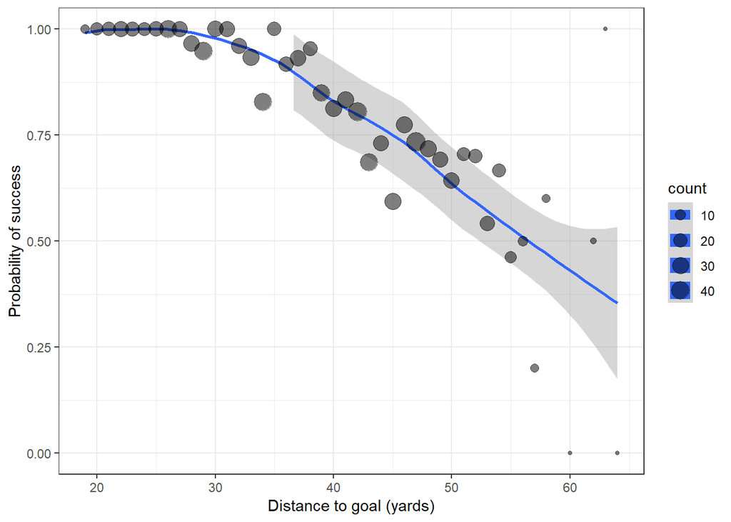

```r
AggData<-aggregate(Data[,c("Dist","Y","B")],by=list(Data$Dist),FUN=mean)

AggData$count<-aggregate(Data[,c("Dist")], by=list(Data$Dist),FUN=length)$x
#AggData<-AggData[AggData$Dist<=65,]
plt<-ggplot(AggData,aes(x=Dist,y=Y,size=count))+geom_smooth(method="loess")+xlab("Distance to goal (yards)")+ylab("Probability of success")+geom_point(alpha=0.5)+ylim(0,1)
plt<-plt+theme_bw()
plt
```

# Model

This model is the same model I used in my [original post](https://jamesblandecon.github.io/NFLFieldGoals.html), but I put these details in here so that we are all on the same page.

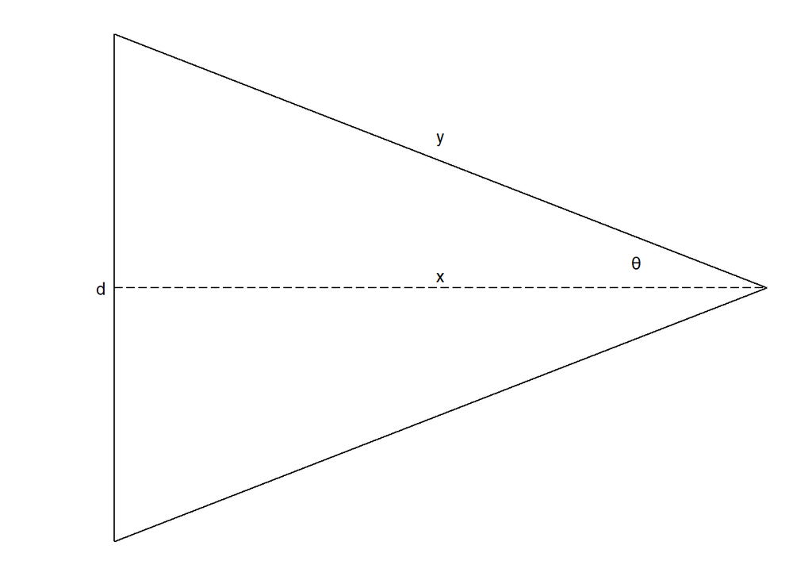

Let $y$ be the hypotenuse of the right-angled triangle made between the ball, the midpoint of the goalposts, and one of the goal posts. This hypotenuse has length: $y=\sqrt{x^2+d^2/4}$. The angle at the ball vertex of this triangle can be found by solving:
$$\begin{aligned}
x&=y\cos\theta\\
x&=\cos\theta\sqrt{x^2+d^2/4}\\
\cos\theta&=\frac{x}{\sqrt{x^2+d^2/4}}\\
\theta&=\cos^{-1}\left(\frac{x}{\sqrt{x^2+d^2/4}}\right)
\end{aligned}$$
And hence the angle of tolerance for a field goal at the $x$-yard line is $\pm\theta$.

Now suppose that the actual angle of a kick, where $\theta=0$ corresponds to a straight kick, is distributed $N(0,\kappa)$. The probability of getting the angle right on a kick is therefore:
$$\Pr\left(\text{angle good} \mid x,\kappa\right)=1-2\Phi\left(-\kappa^{-1}\cos^{-1}\left(\frac{x}{\sqrt{x^2+d^2/4}}\right)\right)$$

This model has one parameter, $\kappa$, which must be positive. I use $\log\kappa \sim N(\log(0.1),1)$ the prior. The prior is the only difference between this and my previous applications. I am using my understanding of what a reasonable value for $\kappa$ is, and then adding a relatively huge variance to my actual understanding.

# Estimating the model in Stan

```c
// FieldGoalsCountLogNormal.stan
functions {


}
data {
  // Tell Stan how to read in the data
  int n; // Number of observations
  vector[n] Angle;
  int y[n]; // =count of scored
  int N[n]; // number of attempts from that distance
  real priorK[2];

}
transformed data {

}
parameters {
  real<lower=0> k;

}
transformed parameters {

}
model {
    vector[n] p;
    k ~ lognormal(priorK[1],priorK[2]);


    for (ii in 1:n) {
        p[ii] =  1-2*normal_cdf((-Angle[ii]),0.0,k);

    }


  y ~ binomial(N,p);


  }
generated quantities {

}
```

# Fitting the model to pooled data

Assuming that all kickers are equally accurate, Stan gives me a posterior distribution like this:

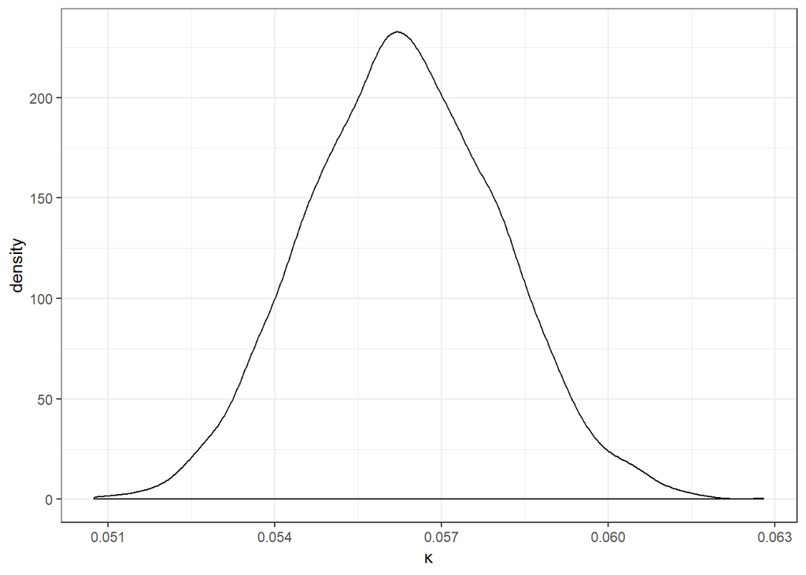

```r
  ksim<-extract(FitALL)$k
  plt<-ggplot()+geom_density(aes(x=ksim))
  plt<-plt+xlab("\u03BA")+theme_bw()
  plt
```

But it is somewhat more useful to look at the model’s predictions of success as a function of distance:

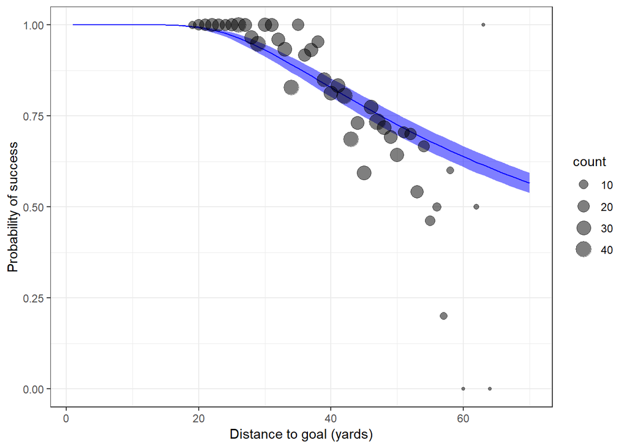

```r
  x<- seq(1,70,1)
  angle<-acos(x/sqrt(x^2+d^2/4))
  pm <- x
  pl <- x
  pr <- x
  for (xx in 1:length(x)) {
    psim<-1-2*pnorm(-angle[xx],0,ksim)
    pm[xx]<-mean(psim)
    pl[xx]<-quantile(psim,probs=0.025)
    pr[xx]<-quantile(psim,probs=0.975)
  }
  data<-data.frame(x,pm,pl,pr)

  plt<-ggplot()+geom_line(data=data,aes(x=x,y=pm),color="blue")
  plt<-plt+geom_ribbon(data=data,aes(x=x,ymin=pl,ymax=pr),linetype="blank",fill="blue",alpha=0.5)
  plt<-plt+geom_point(data=AggData,aes(x=Dist,y=Y,size=count),alpha=0.5)
  plt<-plt+xlab("Distance to goal (yards)")+ylab("Probability of success")+ylim(0,1)
  plt<-plt+theme_bw()
  plt
```

So not a particularly good fit, but my main point of this was to do player rankings, so here we go …

# Player rankings

I estimated the model on each kicker separately, excluding those who made fewer that 5 attempts. Here are the rankings based on posterior mean $\kappa$ (smaller is better):

```r
  PlayerK<-aggregate(SimPlayer[,c("k","Attempts","SuccessRate")],by=list(SimPlayer$Player),FUN=mean)
  # add in credible regions
  kl<-aggregate(SimPlayer[,c("k")],by=list(SimPlayer$Player),FUN= function(x) quantile(x,0.025))
  kr<-aggregate(SimPlayer[,c("k")],by=list(SimPlayer$Player),FUN= function(x) quantile(x,0.975))
  PlayerK$kl<-kl$x
  PlayerK$kr<-kr$x
  PlayerK$LastName<-sub(".* ","",PlayerK$Group.1)
  PlayerK[order(PlayerK$k),c("Group.1","k","SuccessRate","Attempts","kl","kr")]
```

```
##               Group.1          k SuccessRate Attempts         kl         kr
## 22        Kai Forbath 0.03188856   1.0000000       11 0.01672688 0.06011506
## 19         Josh Lambo 0.03769564   0.9705882       34 0.02458807 0.05461369
## 20      Justin Tucker 0.03871100   0.9677419       31 0.02534967 0.05595542
## 9          Dan Bailey 0.04452428   0.9375000       32 0.03068451 0.06258375
## 8       Chris Boswell 0.04522666   0.9354839       31 0.03021760 0.06415635
## 14    Harrison Butker 0.04628658   0.9230769       39 0.03325314 0.06298788
## 23       Mason Crosby 0.04708040   0.9166667       24 0.03067656 0.06868856
## 36           Wil Lutz 0.05141009   0.8717949       39 0.03756765 0.06923402
## 4     Brandon McManus 0.05147419   0.8529412       34 0.03671545 0.07082628
## 30      Randy Bullock 0.05201468   0.8709677       31 0.03625746 0.07320954
## 15       Jake Elliott 0.05265890   0.8620690       29 0.03625521 0.07559141
## 38      Zane Gonzalez 0.05303579   0.9117647       34 0.03673511 0.07404944
## 3      Austin Seibert 0.05433073   0.8620690       29 0.03805770 0.07700277
## 37       Younghoe Koo 0.05474717   0.8846154       26 0.03811454 0.07810866
```

[output cut: 24 more lines]

So here I have sorted by posterior mean $\kappa$, but also show each player’s number of attempts, and “Success Rate”, which is the average success, unconditional of distance. These rankings do not line up exactly:

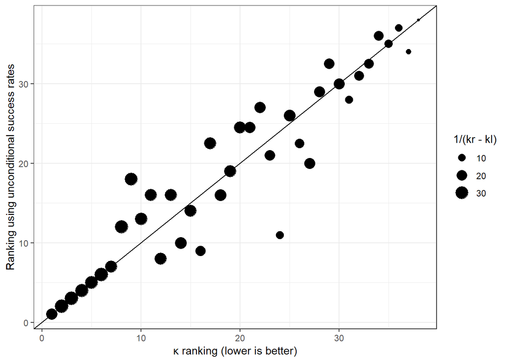

```r
  plt<-ggplot(data=PlayerK,aes(y=rank(1/SuccessRate),x=rank(k),label=LastName))+geom_point(aes(size=1/(kr-kl)))+theme_bw()+geom_abline(intercept=0,slope=1)
  plt<-plt+xlab("\u03BA ranking (lower is better)")+ylab("Ranking using unconditional success rates")
  plt
```

That is, on the horizontal axis I have my own rankings based on $\kappa$ (lower is better), and on the vertical axis I just have the average success rate for that player. I also show how certain I am about $\kappa$ by making the dot size inversely proportional to the size of the 95% credible region on $\kappa$ (i.e. larger means more certain).

It is a bit hard to see the player names associated with these dots if I overlay them on the above plot, so here they are:

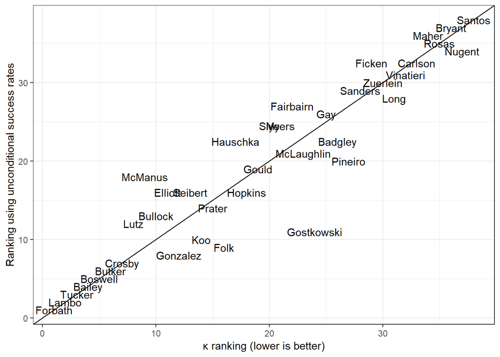

```r
  plt<-ggplot(data=PlayerK,aes(y=rank(1/SuccessRate),x=rank(k),label=LastName))+geom_text()+theme_bw()
  plt<-plt+xlab("\u03BA ranking (lower is better)")+ylab("Ranking using unconditional success rates")+geom_abline(intercept=0,slope=1)
  plt
```

The way to read this is that, for example, that Gostkowski looks much better using the unconditional success rate than if one used my estimates of $\kappa$.

And finally, because I am a sucker for animated GIFs, here are the model’s predictions for each player individually:

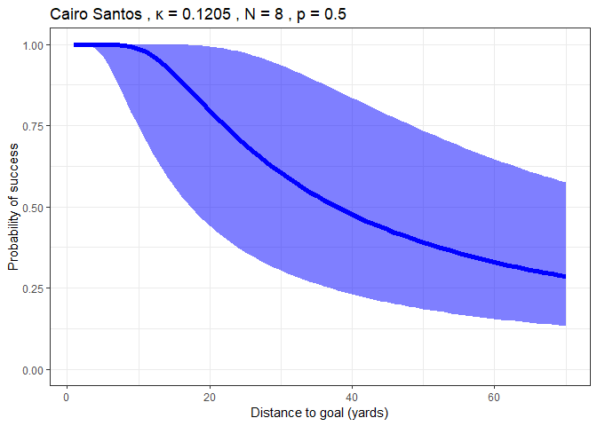

```r
PlayerK<-PlayerK[order(-PlayerK$k),]
GIFdata<-data.frame()
x<-seq(1,70)
for (ii in 1:dim(PlayerK)[1]) {
  pl<-1-2*pnorm(-angle,0,PlayerK[ii,]$kl)
  pr<-1-2*pnorm(-angle,0,PlayerK[ii,]$kr)
  p<-1-2*pnorm(-angle,0,PlayerK[ii,]$k)
  state<-paste(PlayerK[ii,]$Group.1,", \u03BA =",round(PlayerK[ii,]$k,4),", N =",PlayerK[ii,]$Attempts,", p =",round(PlayerK[ii,]$SuccessRate,2))
  tmp<-data.frame(x,pl,pr,state,p)
  GIFdata<-rbind(GIFdata,tmp)
}


  plt<-ggplot(data=GIFdata,aes(x=x,ymin=pl,ymax=pr,y=p))+geom_ribbon(linetype="blank",fill="blue",alpha=0.5)
  plt<-plt+geom_line(color="blue",size=2)
  plt<-plt+transition_states(state,transition_length=5,state_length=5)
  plt<-plt+labs(title = '{closest_state}')
  plt<-plt+xlab("Distance to goal (yards)")+ylab("Probability of success")+ylim(0,1)
  plt<-plt+theme_bw()
  animate(plt, nframes = 10*dim(PlayerK)[1])
```

See [here](https://sites.google.com/site/jamesbland/code-examples) for more of my coding examples!